# Examen statistique sous R

Rédigé par : Khadidiatou COULIBALY Sous la supervision de : M. Aboubacar Hema Research Analyst

Année scolaire : 2024/2025

# Analyse de consistence des bases de données:

## Dimension et variables

### Base main

```
## [1] 8950  100
```

### Base MAD

```
## [1] 2206   26
```

```
##  [1] "MAD_sex"          "MAD_resp_age"     "EverBreastF"      "PCIYCBreastF"
##  [5] "PCIYCInfFormNb"   "PCIYCDairyMiNb"   "PCIYCDairyYoNb"   "PCIYCStapPoNb"
##  [9] "PCMADStapCer"     "PCMADVegOrg"      "PCMADStapRoo"     "PCMADVegGre"
## [13] "PCMADFruitOrg"    "PCMADVegFruitOth" "PCMADPrMeatO"     "PCMADPrMeatF"
## [17] "PCMADPrEgg"       "PCMADPrFish"      "PCMADPulse"       "PCMADDairy"
## [21] "PCMADFatRpalm"    "PCMADSnfChild"    "PCMADSnfPowd"     "PCMADSnfLns"
## [25] "PCIYCMeals"       "ID"
```

## Suppression des colonnes et lignes vides

```
## [1] 8950   97
```

Il y avait 3 colonnes vides.

```
## [1] 2206   26
```

Aucune ligne ou colonne vide avant.

## Vérification de doublons

Il n’y a pas de doublons dans la base principale.

```
## No variable names specified - using all columns.
```

```
## No duplicate combinations found of: ID, SvyDate, YEAR, SvyMonth, SURVEY, ADMIN0Name, adm0_ocha, ADMIN1Name, adm1_ocha, ... and 88 other variables
```

```
## No variable names specified - using all columns.
```

Il y a deux lignes qui se répètent. La question est de savoir si effectivement il s’agit de doublons.

```
## [1] 2020
```

Mais comme toutes les variables ont les mêmes valeurs, on suppose que ce sont des doublons. Supprimons les.

# Analyse des données et calcul d’indicateurs

## Analyse socio-démographique des ménages

Prenons les variables socio-démongraphiques et tabulons les.

Construisons un tableau pour elles. On créer aussi une variable contenant le nombre d’hommes et une le nombre de femmes dans la maison

Caractéristiques socio-démographiques des ménages

| **Characteristic** | **N = 8,950**<sup>1</sup> |
| --- | --- |
| Region (ADMIN1) where the household is located |  |
| Barh-El-Gazel | 1,200 (13%) |
| Batha | 1,605 (18%) |
| Ennedi Est | 229 (2.6%) |
| Guera | 1,399 (16%) |
| Kanem | 1,234 (14%) |
| Lac | 1,418 (16%) |
| Ouaddai | 928 (10%) |
| Salamat | 480 (5.4%) |
| Sila | 446 (5.0%) |
| Wadi Fira | 11 (0.1%) |
| household size | 7.5 (12.9, 0.0, 352.0) |
| What is the sex of the head of household? |  |
| Femme | 3,938 (44%) |
| Homme | 5,012 (56%) |
| What is the age of the head of household (in years)? | 42.9 (12.6, 15.0, 96.0) |
| What is the level of education attained by the head of household? |  |
| Aucune | 1,827 (31%) |
| Alphabétisé ou Coranique | 3,684 (62%) |
| Primaire | 265 (4.5%) |
| Secondaire | 126 (2.1%) |
| Superieur | 24 (0.4%) |
| Unknown | 3,024 |
| What is the source of income of the head of household? |  |
| Agriculture vivrière/ou de rente (hors maraîchage) | 861 (50%) |
| Élevage | 27 (1.6%) |
| Vente des produits maraîchers | 187 (11%) |
| Vente d'animaux ou de produits d'élevage (lait, fromage, œufs, …) | 5 (0.3%) |
| Vente de produits de la pêche | 34 (2.0%) |
| Vente de produits de chasse/cueillette | 21 (1.2%) |
| Commerce des produits alimentaires ou animaux non produits par le ménage lui-même | 33 (1.9%) |
| Petit commerce de produits non alimentaires | 66 (3.9%) |
| Artisanat/Petits métiers | 85 (5.0%) |
| Travail journalier | 154 (9.0%) |
| Salarié/Pension | 25 (1.5%) |
| Transport | 11 (0.6%) |
| Aides/dons et transfert d'argent | 105 (6.1%) |
| Travail spécialisé (mécanicien, maçon, tailleur, coiffeur, gros commerce/commerce formel) | 31 (1.8%) |
| Autres | 67 (3.9%) |
| Unknown | 7,238 |
| HHSizeM | 3.7 (6.4, 0.0, 335.0) |
| HHSizeF | 3.5 (5.1, 0.0, 125.0) |

<sup>1</sup> n (%); Mean (SD, Range)

### Analyse

L’enquête porte sur un échantillon de 8 950 ménages répartis dans l’ensemble des régions étudiées. Batha (18 %) et Lac (16 %) arrivent en tête du classement, suivies de près par Guéra (16 %) et Kanem (14 %). Les autres régions affichent des proportions plus modestes : Ouaddaï (10 %), Salamat (5,4 %), Sila (5 %) et Ennedi Est (2,6 %). Notons enfin que Wadi Fira ne représente que 0,1 % de l’échantillon (11 ménages), ce qui peut traduire une couverture locale limitée ou un faible taux de réponse.

La taille moyenne des ménages de l’étude est de 7,5 personnes, avec un écart-type élevé de 12,9. Les valeurs extrêmes vont de 0 à 352 individus, suggérant la présence possible de codages particuliers ou d’unités de recueil atypiques. Cette large dispersion incite à vérifier la qualité des données avant toute analyse fine, notamment pour s’assurer que les ménages de taille nulle ou très élevée correspondent à des cas réels et non à des erreurs de saisie.

Les chefs de ménage sont majoritairement des hommes (56 %), tandis que les femmes représentent 44 % des cas. L’âge moyen est de 42,9 ans (écart-type : 12,6), avec un minimum observé à 15 ans et un maximum à 96 ans. Cette répartition montre une relative homogénéité générationnelle, tout en soulignant la présence de chefs très jeunes et très âgés.

En matière d’instruction, près d’un tiers des chefs de ménage (31 %) déclarent n’avoir aucun niveau formel, et la grande majorité (62 %) se situe dans la catégorie « alphabétisé ou coranique ». Les niveaux primaire (4,5 %), secondaire (2,1 %) et supérieur (0,4 %) sont beaucoup moins fréquents. Par ailleurs, environ un tiers des répondants (34 %) sont codés « Unknown », indiquant des données manquantes ou non renseignées qui pourraient mériter une exploration ou une imputation lors des analyses ultérieures.

La moitié des chefs de ménage tire ses revenus de l’agriculture vivrière ou de rente hors maraîchage (50 %, soit 861 ménages). Viennent ensuite la vente de produits maraîchers (11 %, 187 cas) et le travail journalier (9 %, 154 cas). Les autres activités génératrices de revenus — artisanat/petits métiers (5 %), aides ou transferts d’argent (6 %), petit commerce non alimentaire (4 %) — sont relativement minoritaires. Les sources très spécialisées (élevage, pêche, transport, salarié/pension) représentent chacune moins de 2 % des cas. Enfin, un nombre important de répondants (7 238 ménages, soit environ 81 %) est codé « Unknown », ce qui suggère un effort à faire pour améliorer la collecte ou le codage de cette information.

En moyenne, chaque ménage compte 3,7 hommes (écart-type 6,4, min 0, max 335) et 3,5 femmes (écart-type 5,1, min 0, max 125). Ces valeurs confirment que la composition par sexe est globalement équilibrée, tout en révélant une forte hétérogénéité — notamment des ménages où un seul des deux genres prédomine de manière exceptionnelle. Une vérification des cas extrêmes (plus de 50 individus d’un même sexe) est néanmoins recommandée pour s’assurer qu’il ne s’agit pas d’erreurs de saisie.

## Score de consommation alimentaire (SCA - Food Consumption score):

Le score de consommation alimentaire, aussi appelé score de diversité alimentaire (SCA) ou score de qualité de l’alimentation, est un outil essentiel pour évaluer la variété et la qualité de l’alimentation d’une personne ou d’un groupe. Ce score se base sur la consommation de différents groupes d’aliments sur une période donnée, généralement une journée ou une semaine. Il permet d’obtenir une vue d’ensemble sur la diversité des aliments ingérés et la qualité nutritionnelle de l’alimentation.

### Variables qui composent le SCA

Prenons les variables qui peuvent nous interesser. On prend alors celles qui commencent par FCS.

```
##  [1] "FCSStap"     "FCSPulse"    "FCSDairy"    "FCSPr"       "FCSPrMeatF"
##  [6] "FCSPrMeatO"  "FCSPrFish"   "FCSPrEgg"    "FCSVeg"      "FCSVegOrg"
## [11] "FCSVegGre"   "FCSFruit"    "FCSFruitOrg" "FCSFat"      "FCSSugar"
## [16] "FCSCond"
```

Tabulons les pour voir.

Variables du FCS

| **Characteristic** | **N = 8,950**<sup>1</sup> |
| --- | --- |
| Consumption over the past 7 days: cereals, grains and tubers |  |
| 0 | 54 (0.6%) |
| 1 | 81 (0.9%) |
| 2 | 64 (0.7%) |
| 3 | 79 (0.9%) |
| 4 | 82 (0.9%) |
| 5 | 251 (2.8%) |
| 6 | 345 (3.9%) |
| 7 | 7,994 (89%) |
| Consumption over the past 7 days: pulses |  |
| 0 | 2,516 (28%) |
| 1 | 824 (9.2%) |
| 2 | 1,917 (21%) |
| 3 | 1,665 (19%) |
| 4 | 864 (9.7%) |
| 5 | 489 (5.5%) |
| 6 | 120 (1.3%) |
| 7 | 555 (6.2%) |
| Consumption over the past 7 days: dairy products |  |
| 0 | 4,045 (45%) |
| 1 | 785 (8.8%) |
| 2 | 1,318 (15%) |
| 3 | 1,096 (12%) |
| 4 | 602 (6.7%) |
| 5 | 217 (2.4%) |
| 6 | 47 (0.5%) |
| 7 | 840 (9.4%) |
| Consumption over the past 7 days: meat, fish and eggs |  |
| 0 | 1,749 (20%) |
| 1 | 2,009 (22%) |

[output cut: 120 more lines]

<sup>1</sup> n (%)

### Calculons le SCA.

Nous utilisons le [document](https://library.ipcinfo.org/Acute%20Food%20Insecurity/IPC%20Level%202%20Training/English/Virtual%20Modality/Supporting%20Materials/Session%201/FCS/FCS%202008.pdf) décrivant comment est calculé le FCS.

L’image suivante montre aussi la méthode de calcul.

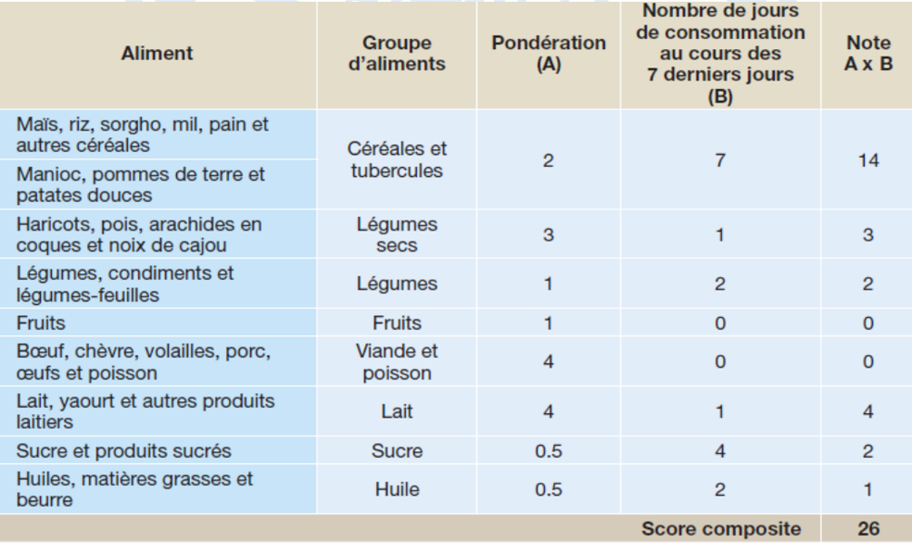

Nous ne prenons pas en compte les fruits oranges et la comsommation de légumes verts car on les considère comme des sous parties.

### Tableau illustrant le poids de chaque groupe alimentaire

| groupe | poids |
| --- | --- |
| cereals, grains and tubers | 2 |
| pulses | 3 |
| meat, fish and eggs | 4 |
| dairy product | 4 |
| vegetables | 1 |
| fruit | 1 |
| fat and oil | 0.5 |
| sugaror sweets | 0.5 |
| condiments or spices | 0 |

### Catégorisons

Nous utilisons l’image suivant pour nous gider dans les catégories.

[figure not shown]

Tabulons pour voir et faire une petite analyse.

Score de consommation alimentaire

| **Characteristic** | **N = 8,950**<sup>1</sup> |
| --- | --- |
| Score de consommation alimentaire | 47 (17, 0, 112) |
| Catégories SCA seuil 21 35 |  |
| Acceptable | 6,747 (75%) |
| Limite | 1,757 (20%) |
| Pauvre | 446 (5.0%) |
| Catégories SCA seuil 28 42 |  |
| Acceptable | 5,245 (59%) |
| Limite | 2,569 (29%) |
| Pauvre | 1,136 (13%) |

<sup>1</sup> Mean (SD, Range); n (%)

Le score de consommation alimentaire (SCA) moyen des ménages est estimé à 47, avec un écart-type de 17, et des valeurs comprises entre 0 et 112. Cela reflète une diversité importante dans les habitudes alimentaires des ménages. En appliquant les seuils standards du PAM (seuil 21), une large majorité des ménages (75 %) présente une consommation acceptable, tandis que 20 % se situent en zone limite et 5 % en situation de consommation pauvre, signalant une insécurité alimentaire préoccupante.

Cependant, l’utilisation d’un seuil plus strict (seuil 28) modifie la répartition : seuls 59 % des ménages sont alors considérés comme ayant une consommation acceptable, contre 29 % en situation limite et 13 % en situation pauvre. Cette seconde lecture permet d’identifier une proportion plus élevée de ménages potentiellement vulnérables, mettant en évidence la sensibilité de l’analyse aux seuils choisis pour le classement.

### Représentation graphique

[figure not shown]

## L’indice réduit des stratégies de survie (rCSI):

### Variables qui composent le rCSI

Prenons les variables qui peuvent nous interesser. On prend alors celles qui commencent par rCSI.

Tabulons les pour voir.

Variables du rCSI

| **Characteristic** | **N = 8,950**<sup>1</sup> |
| --- | --- |
| Relied on less preferred, less expensive food |  |
| 0 | 4,065 (45%) |
| 1 | 2,233 (25%) |
| 2 | 1,475 (16%) |
| 3 | 633 (7.1%) |
| 4 | 186 (2.1%) |
| 5 | 129 (1.4%) |
| 6 | 36 (0.4%) |
| 7 | 193 (2.2%) |
| Borrowed food or relied on help from friends or relatives |  |
| 0 | 4,209 (47%) |
| 1 | 2,162 (24%) |
| 2 | 1,449 (16%) |
| 3 | 643 (7.2%) |
| 4 | 176 (2.0%) |
| 5 | 111 (1.2%) |
| 6 | 28 (0.3%) |
| 7 | 172 (1.9%) |
| Reduced portion size of meals at meals time |  |
| 0 | 5,543 (62%) |
| 1 | 1,767 (20%) |
| 2 | 994 (11%) |
| 3 | 424 (4.7%) |
| 4 | 124 (1.4%) |
| 5 | 42 (0.5%) |
| 6 | 11 (0.1%) |
| 7 | 45 (0.5%) |
| Restricted consumption by adults in order for young children to eat |  |
| 0 | 6,761 (76%) |
| 1 | 1,319 (15%) |
| 2 | 518 (5.8%) |
| 3 | 227 (2.5%) |
| 4 | 68 (0.8%) |
| 5 | 25 (0.3%) |
| 6 | 4 (<0.1%) |
| 7 | 28 (0.3%) |
| Reduced the number of meals eaten per day |  |
| 0 | 5,737 (64%) |
| 1 | 1,738 (19%) |
| 2 | 898 (10%) |
| 3 | 350 (3.9%) |
| 4 | 120 (1.3%) |
| 5 | 51 (0.6%) |
| 6 | 8 (<0.1%) |
| 7 | 48 (0.5%) |

<sup>1</sup> n (%)

L’analyse des cinq indicateurs composant l’indice réduit des stratégies de survie (rCSI) montre que la majorité des ménages ont eu recours à des stratégies alimentaires de façon limitée au cours des 7 derniers jours.

La stratégie la plus fréquemment rapportée est le recours à des aliments moins préférés ou moins chers, avec 45 % des ménages n’ayant pas eu besoin de le faire, mais 25 % l’ayant utilisée une fois, 16 % deux fois et une minorité allant jusqu’à 7 fois. Cela révèle une pression modérée sur la qualité perçue de l’alimentation.

La stratégie d’emprunt de nourriture ou d’aide de proches suit un profil similaire : 47 % n’y ont pas eu recours, tandis qu’environ 24 % l’ont pratiquée une fois, et près de 16 % deux fois. Ces résultats suggèrent un filet social encore actif, mais sollicité pour près de la moitié des ménages.

Le comportement le moins fréquent est la restriction alimentaire des adultes au profit des enfants, avec 76 % des ménages n’y ayant pas eu recours. Seuls 15 % l’ont pratiquée une fois, ce qui indique que les situations extrêmes de privation ciblée restent minoritaires.

Enfin, la réduction du nombre de repas quotidiens a concerné 36 % des ménages au moins une fois, mais une large majorité (64 %) n’a pas eu à adopter cette stratégie, ce qui traduit un maintien général du rythme alimentaire de base.

### Calculons l’indice rCSI

Nous attribuons un poids à chacune des stratégies.

L’image suivante montre les poids “universels”. Les mêmes poids ont été retrouvés sur le site de [WFP](https://resources.vam.wfp.org/data-analysis/quantitative/food-security/reduced-coping-strategies-index).

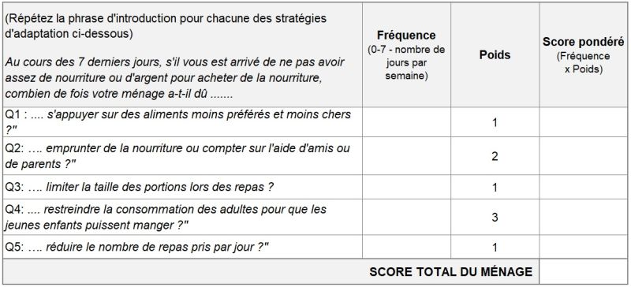

Tabulons un peu

Indice réduit des stratégies de survie

| **Characteristic** | **N = 8,950**<sup>1</sup> |
| --- | --- |
| Indice réduit des stratégies de survie | 6 (7, 0, 56) |

<sup>1</sup> Mean (SD, Range)

L’**indice réduit des stratégies de survie (rCSI)** présente une moyenne de  
5.8 ( avec un écart-type = 7.5), et des valeurs extrêmes allant de 0 à 56.  
Cette distribution suggère qu’en moyenne chaque ménage a eu recours à un nombre modéré de stratégies d’ajustement alimentaire, mais que certains ménages ont dû mobiliser un éventail très large de réponses de survie, témoignant de situations d’insécurité alimentaire particulièrement aiguës.

### Tableau du poids de chaque variable

poids des variables dans le rCSI

| groupe | poids |
| --- | --- |
| rCSILessQlty - Relied on less preferred, less expensive food, grains and tubers | 1 |
| rCSIBorrow - Borrowed food or relied on help from friends or relatives | 2 |
| rCSIMealNb - Reduced the number of meals eaten per day | 1 |
| rCSIMealSize - Reduced portion size of meals at meals time | 1 |
| rCSIMealAdult - Restricted consumption by adults in order for young children to eat | 3 |

## Stratégies d’adaptation aux moyens d’existence (LhCSI)

### Variables qui composent le LhCSI

```
##  [1] "LhCSIStress1"    "LhCSIStress2"    "LhCSIStress3"    "LhCSIStress4"
##  [5] "LhCSICrisis1"    "LhCSICrisis2"    "LhCSICrisis3"    "LhCSIEmergency1"
##  [9] "LhCSIEmergency2" "LhCSIEmergency3"
```

Tabulons les pour voir.

Variables du LhCSI

| **Characteristic** | **N = 8,950**<sup>1</sup> |
| --- | --- |
| Sold household assets/goods (radio, furniture, refrigerator, television, jewelle |  |
| No, because I did not need to | 0 (0%) |
| No, because I already sold those assets or have engaged in this activity within the last 12 months and cannot continue to do it | 0 (0%) |
| Yes | 0 (0%) |
| Not applicable (don't have children/these assets) | 8,950 (100%) |
| Spent savings due to lack of food |  |
| No, because I did not need to | 3,156 (35%) |
| No, because I already sold those assets or have engaged in this activity within the last 12 months and cannot continue to do it | 1,473 (16%) |
| Yes | 420 (4.7%) |
| Not applicable (don't have children/these assets) | 3,901 (44%) |
| Sent household members to eat elsewhere/live with family or friends due to lack |  |
| No, because I did not need to | 2,763 (31%) |
| No, because I already sold those assets or have engaged in this activity within the last 12 months and cannot continue to do it | 1,233 (14%) |
| Yes | 375 (4.2%) |
| Not applicable (don't have children/these assets) | 4,579 (51%) |
| Purchased food/non-food on credit (incur debts) due to lack of food |  |
| No, because I did not need to | 3,258 (36%) |
| No, because I already sold those assets or have engaged in this activity within the last 12 months and cannot continue to do it | 1,384 (15%) |
| Yes | 1,719 (19%) |
| Not applicable (don't have children/these assets) | 2,589 (29%) |
| Sold productive assets or means of transport (sewing machine, wheelbarrow, bicyc |  |
| No, because I did not need to | 3,487 (39%) |
| No, because I already sold those assets or have engaged in this activity within the last 12 months and cannot continue to do it | 1,549 (17%) |
| Yes | 300 (3.4%) |
| Not applicable (don't have children/these assets) | 3,614 (40%) |
| Reduced expenses on health (including drugs) |  |
| No, because I did not need to | 2,870 (32%) |
| No, because I already sold those assets or have engaged in this activity within the last 12 months and cannot continue to do it | 1,269 (14%) |
| Yes | 163 (1.8%) |
| Not applicable (don't have children/these assets) | 4,648 (52%) |
| Withdrew children from school due to lack of food |  |
| No, because I did not need to | 3,231 (36%) |
| No, because I already sold those assets or have engaged in this activity within the last 12 months and cannot continue to do it | 1,397 (16%) |
| Yes | 108 (1.2%) |
| Not applicable (don't have children/these assets) | 4,214 (47%) |
| Mortgaged/Sold house or land due to lack of food |  |
| No, because I did not need to | 3,259 (36%) |
| No, because I already sold those assets or have engaged in this activity within the last 12 months and cannot continue to do it | 1,387 (15%) |
| Yes | 53 (0.6%) |
| Not applicable (don't have children/these assets) | 4,251 (47%) |
| Begged and/or scavenged (asked strangers for money/food) due to lack of food |  |
| No, because I did not need to | 3,140 (35%) |
| No, because I already sold those assets or have engaged in this activity within the last 12 months and cannot continue to do it | 1,437 (16%) |
| Yes | 282 (3.2%) |
| Not applicable (don't have children/these assets) | 4,091 (46%) |
| Engaged in illegal income activities (theft, prostitution) due to lack of food |  |
| No, because I did not need to | 3,138 (35%) |
| No, because I already sold those assets or have engaged in this activity within the last 12 months and cannot continue to do it | 1,379 (15%) |
| Yes | 202 (2.3%) |
| Not applicable (don't have children/these assets) | 4,231 (47%) |

<sup>1</sup> n (%)

Parmi les stratégies plus « financières », l’achat à crédit concerne 19 % des ménages, alors que 36 % n’en ont pas eu besoin et 15 % ont épuisé cette option ; 29 % sont « Not applicable ». La vente d’actifs productifs ou moyens de transport (machine à coudre, brouette, vélo…) reste marginale (3,4 % de « Yes »), avec 39 % de « No, did not need », 17 % de « No, already sold/épuisé » et 40 % de non applicables.

Les stratégies les plus extrêmes — réduction des dépenses de santé (1,8 %), retrait d’enfants de l’école (1,2 %), hypothèque ou vente de maison/terre (0,6 %), mendicité (3,2 %) et recours à des activités illicites (2,3 %) — sont peu fréquentes, la très grande majorité des ménages déclarant ne pas en avoir eu besoin (31–36 %) ou relevant de la catégorie « Not applicable » (46–52 %).

## Score de diversité alimentaire des ménages:

### Variables qui composent le SDA

```
##  [1] "HDDS_CH"      "HDDSStapCer"  "HDDSStapRoot" "HDDSPulse"    "HDDSVegOrg"
##  [6] "HDDSVegGre"   "HDDSVegOth"   "HDDSFruitOrg" "HDDSFruitOth" "HDDSPrMeatF"
## [11] "HDDSPrMeatO"  "HDDSPrFish"   "HDDSPrEgg"    "HDDSDairy"    "HDDSSugar"
## [16] "HDDSFat"      "HDDSCond"     "HDDSPrMeat"
```

Tabulons les pour voir.

Variables du HDDS

| **Characteristic** | **N = 8,950**<sup>1</sup> |
| --- | --- |
| CH Household Dietary Diversity Score |  |
| 1 | 2,427 (74%) |
| 2 | 403 (12%) |
| 3 | 202 (6.1%) |
| 4 | 142 (4.3%) |
| 5 | 117 (3.6%) |
| Unknown | 5,659 |
| household eat/consume the following foods yesterday: Rice, pasta, bread, sorghum |  |
| Non | 412 (4.6%) |
| Oui | 8,509 (95%) |
| Unknown | 29 |
| household eat/consume the following foods yesterday: Potato, yam, cassava, white |  |
| Non | 6,129 (69%) |
| Oui | 2,792 (31%) |
| Unknown | 29 |
| household eat/consume the following foods yesterday: Beans, cowpeas, peanuts, le |  |
| Non | 3,518 (48%) |
| Oui | 3,749 (52%) |
| Unknown | 1,683 |
| household eat/consume the following foods yesterday: Orange vegetables (vegetabl |  |
| Non | 3,697 (91%) |
| Oui | 376 (9.2%) |
| Unknown | 4,877 |
| household eat/consume the following foods yesterday: Green leafy vegetables |  |
| Non | 2,886 (49%) |
| Oui | 2,970 (51%) |
| Unknown | 3,094 |
| household eat/consume the following foods yesterday: Other vegetables |  |
| Non | 2,768 (42%) |
| Oui | 3,834 (58%) |
| Unknown | 2,348 |
| household eat/consume the following foods yesterday: Orange fruits (Fruits rich |  |
| Non | 3,309 (96%) |
| Oui | 145 (4.2%) |
| Unknown | 5,496 |
| household eat/consume the following foods yesterday: Other fruits |  |
| Non | 3,278 (87%) |
| Oui | 474 (13%) |
| Unknown | 5,198 |
| household eat/consume the following foods yesterday: Flesh meat |  |
| Non | 4,269 (69%) |
| Oui | 1,953 (31%) |
| Unknown | 2,728 |
| household eat/consume the following foods yesterday: Organ meat |  |
| Non | 3,544 (85%) |
| Oui | 620 (15%) |
| Unknown | 4,786 |
| household eat/consume the following foods yesterday: Fish, including canned tuna |  |
| Non | 3,096 (57%) |
| Oui | 2,350 (43%) |
| Unknown | 3,504 |
| household eat/consume the following foods yesterday: Eggs |  |
| Non | 3,368 (94%) |
| Oui | 229 (6.4%) |
| Unknown | 5,353 |
| household eat/consume the following foods yesterday: Fresh milk/sour, yogurt, ch |  |
| Non | 3,149 (49%) |
| Oui | 3,249 (51%) |
| Unknown | 2,552 |
| household eat/consume the following foods yesterday: Sugar, honey, jam, cakes, c |  |
| Non | 1,346 (16%) |
| Oui | 6,826 (84%) |
| Unknown | 778 |
| household eat/consume the following foods yesterday: Vegetable oil, palm oil, sh |  |
| Non | 1,192 (14%) |
| Oui | 7,447 (86%) |
| Unknown | 311 |
| household eat/consume the following foods yesterday: Tea, coffee/cocoa, salt, ga |  |
| Non | 1,087 (13%) |
| Oui | 7,515 (87%) |
| Unknown | 348 |
| household eat/consume the following foods yesterday: Goat, beef, chicken, pork, |  |
| Non | 4,036 (45%) |
| Oui | 4,914 (55%) |

<sup>1</sup> n (%)

## Calculons le score

Score de diversité alimentaire

| **Characteristic** | **N = 8,950**<sup>1</sup> |
| --- | --- |
| SDA | 6.48 (2.59, 0.00, 17.00) |

<sup>1</sup> Mean (SD, Range)

## Score de résilience auto-évaluée (SERS):

### Variables qui composent le SERS

```
##  [1] "SERSRebondir"          "SERSRevenue"           "SERSMoyen"
##  [4] "SERSDifficultes"       "SERSSurvivre"          "SERSFamAmis"
##  [7] "SERSPoliticiens"       "SERSLecons"            "SERSPreparerFuture"
## [10] "SERSAvertissementEven"
```

Tabulons les pour voir.

Variables du SERS

| **Characteristic** | **N = 8,950**<sup>1</sup> |
| --- | --- |
| Your household can bounce back from any climatic, economic or socio-political ch |  |
| tout à fait d'accord | 2,465 (28%) |
| d'accord | 3,461 (39%) |
| ni d'accord ni pas d'accord | 888 (9.9%) |
| pas d'accord | 1,733 (19%) |
| pas du tout d'accord | 403 (4.5%) |
| If affected by a climate, economic or socio-political challenge, your household |  |
| tout à fait d'accord | 2,146 (24%) |
| d'accord | 3,766 (42%) |
| ni d'accord ni pas d'accord | 1,069 (12%) |
| pas d'accord | 1,656 (19%) |
| pas du tout d'accord | 313 (3.5%) |
| If the climatic, economic or socio-political threats to your household become mo |  |
| tout à fait d'accord | 1,810 (20%) |
| d'accord | 3,384 (38%) |
| ni d'accord ni pas d'accord | 1,346 (15%) |
| pas d'accord | 2,018 (23%) |
| pas du tout d'accord | 392 (4.4%) |
| Your household could easily access the financial support it would need if it wer |  |
| tout à fait d'accord | 2,181 (24%) |
| d'accord | 3,208 (36%) |
| ni d'accord ni pas d'accord | 1,030 (12%) |
| pas d'accord | 2,129 (24%) |
| pas du tout d'accord | 402 (4.5%) |
| Your household can afford everything it needs to survive and prosper |  |
| tout à fait d'accord | 1,518 (17%) |
| d'accord | 3,136 (35%) |
| ni d'accord ni pas d'accord | 1,428 (16%) |
| pas d'accord | 2,308 (26%) |
| pas du tout d'accord | 560 (6.3%) |
| In the event of unmet basic needs due to events/shocks/stress (climatic OR econo |  |
| tout à fait d'accord | 2,870 (32%) |
| d'accord | 3,972 (44%) |
| ni d'accord ni pas d'accord | 948 (11%) |
| pas d'accord | 968 (11%) |
| pas du tout d'accord | 192 (2.1%) |
| In the event of basic needs not being met due to events/shocks/stress (climatic |  |
| tout à fait d'accord | 2,815 (31%) |
| d'accord | 3,318 (37%) |
| ni d'accord ni pas d'accord | 1,206 (13%) |
| pas d'accord | 1,307 (15%) |
| pas du tout d'accord | 304 (3.4%) |
| Your household has learned important lessons from past difficulties caused by ev |  |
| tout à fait d'accord | 2,090 (23%) |
| d'accord | 3,767 (42%) |
| ni d'accord ni pas d'accord | 1,222 (14%) |
| pas d'accord | 1,574 (18%) |
| pas du tout d'accord | 297 (3.3%) |
| Your household is fully prepared for any future event/shock/stress (climatic OR |  |
| tout à fait d'accord | 1,491 (17%) |
| d'accord | 3,065 (34%) |
| ni d'accord ni pas d'accord | 1,489 (17%) |
| pas d'accord | 2,290 (26%) |
| pas du tout d'accord | 563 (6.3%) |
| Unknown | 52 |
| Your household receives advance warning of future variability (climatic OR econo |  |
| tout à fait d'accord | 1,987 (22%) |
| d'accord | 2,896 (33%) |
| ni d'accord ni pas d'accord | 1,183 (13%) |
| pas d'accord | 2,190 (25%) |
| pas du tout d'accord | 626 (7.0%) |
| Unknown | 68 |

<sup>1</sup> n (%)

## Régime alimentaire minimum acceptable (MAD)

## Nombre de groupes d’aliments consommé par un enfant

On prend les enfants qui nous interessent, les enfants de 6 à 23 mois.

Voyons le nombre de groupe alimentaires consommés

### Si l’enfant a consommé au moins cinq groupes d’aliments…

Tabulons les 2 pour voir

Groupe alimentaires consommés par les enfants

| **Characteristic** | **N = 2,204**<sup>1</sup> |
| --- | --- |
| Nb_groups | 2.75 (2.72, 0.00, 12.00) |
| Nb_groups_5 |  |
| Non | 1,768 (80%) |
| Yes | 436 (20%) |

<sup>1</sup> Mean (SD, Range); n (%)

### Les enfants disposant d’un régime alimentaire au minimum acceptable

Fusions pour cela nos bases

Tabulons maintenant avec le SCA

```
## 389 observations missing `SCA_21_35` have been removed. To include these observations, use `forcats::fct_na_value_to_level()` on `SCA_21_35` column before passing to `tbl_summary()`.
```

```
## 389 observations missing `SCA_28_42` have been removed. To include these observations, use `forcats::fct_na_value_to_level()` on `SCA_28_42` column before passing to `tbl_summary()`.
```

Différents régimes d’alimentation

| **Characteristic** | Seuil SCA 21–35 **Acceptable**, N = 1,324<sup>1</sup> | Seuil SCA 21–35 **Limite**, N = 379<sup>1</sup> | Seuil SCA 21–35 **Pauvre**, N = 112<sup>1</sup> | Seuil SCA 28–42 **Acceptable**, N = 987<sup>1</sup> | Seuil SCA 28–42 **Limite**, N = 563<sup>1</sup> | Seuil SCA 28–42 **Pauvre**, N = 265<sup>1</sup> |
| --- | --- | --- | --- | --- | --- | --- |
| Nb_groups_5 |  |  |  |  |  |  |
| Non | 1,066 (81%) | 318 (84%) | 103 (92%) | 759 (77%) | 492 (87%) | 236 (89%) |
| Yes | 258 (19%) | 61 (16%) | 9 (8.0%) | 228 (23%) | 71 (13%) | 29 (11%) |

<sup>1</sup> n (%)

#### Statistique suivi le chef de ménage et l’année

On considère acceptable suivant le premier seuil 21 _ 35.

Enfants dispocant d’un régime acceptable Suivant l’année et le sexe

| **Characteristic** | Sexe du chef de ménage **Femme**, N = 536<sup>1</sup> | Sexe du chef de ménage **Homme**, N = 788<sup>1</sup> | nnnée **2022**, N = 581<sup>1</sup> | nnnée **2023**, N = 743<sup>1</sup> |
| --- | --- | --- | --- | --- |
| Nb_groups_5 |  |  |  |  |
| Non | 444 (83%) | 622 (79%) | 480 (83%) | 586 (79%) |
| Yes | 92 (17%) | 166 (21%) | 101 (17%) | 157 (21%) |

<sup>1</sup> n (%)